# 8_2_ARMA_Homework

```r
library(fpp3)
library(patchwork)
```

**NOTE**: if at any point you encounter a situation where both ACF and PACF seem to cut off then fit two models: 1. Model suggested by the cut-off of the ACF. 2. Model suggested by the cut-off of the PACF.

# Exercise 1

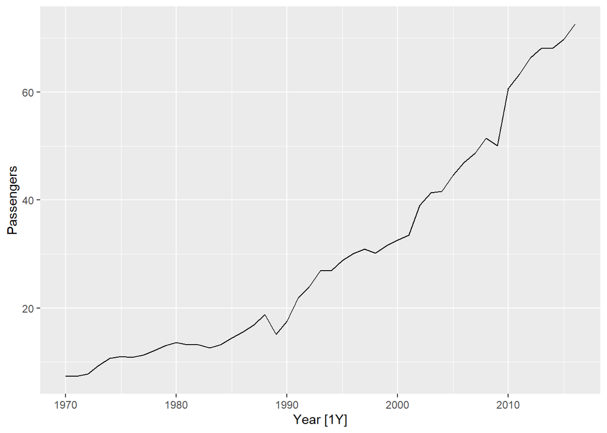

```r
aus_airpassengers %>% autoplot(Passengers)
```

1. Check that applying 2-nd order differences results in a stationary time series. That is:
- Take first-order differences of Passengers and call the result `diff`
- Take subsequent first-order differences of `diff` to obtain the second order differences and call it `diff2`

```r
aus_airpassengers <-
  aus_airpassengers %>%
    mutate(
            diff = difference(Passengers, 1),
            diff2 = difference(diff, 1)
          )

# aus_airpassengers %>% autoplot(diff)
# aus_airpassengers %>% autoplot(diff2)

aus_airpassengers %>%
  features(diff2, unitroot_kpss)
```

```
# A tibble: 1 × 2
  kpss_stat kpss_pvalue
      <dbl>       <dbl>
1    0.0361         0.1
```

2. The second order differences are a stationary process and, as such, an ARMA(p,q) model is sensible for this time series.

2.1 Plot the ACF and PACF of the second order differences (use `gg_tsdisplay`):

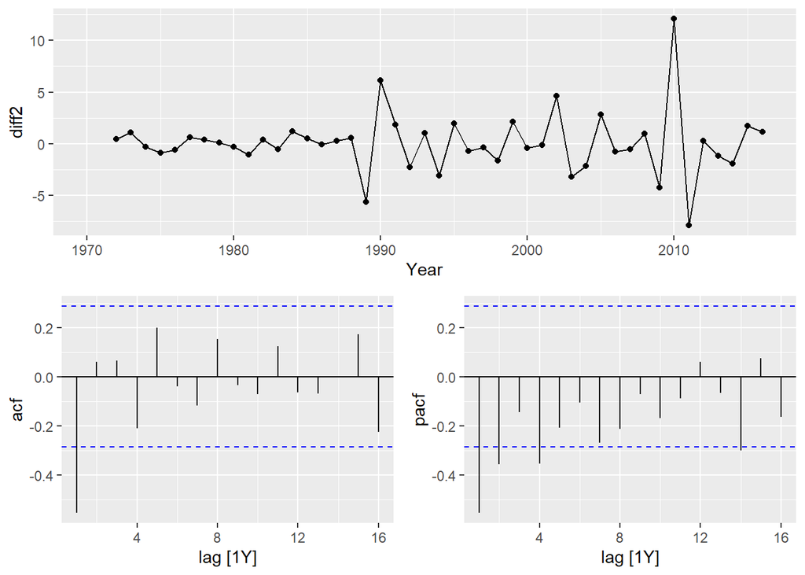

```r
aus_airpassengers %>% gg_tsdisplay(diff2, plot_type="partial")
```

2.2 Propose and fit one or more sensible for `diff2` models based on the graphs above. Also fit an automatically fitted model using `ARIMA(diff2)` with no further arguments.

```r
# acf seems to clearly cut-off

# It is unclear from the graph whether pacf tails-off or cuts-off. We therefore
# propose two models:

# Model 1: assume ACF cuts-off and PACF tails-off. This is an MA(1)

# Model 2: assume PACF cuts-off. ACF does not tail off, but we will fit
# an AR(4) matching the cut-off on the pacf.

fit <-
  aus_airpassengers %>%
    model(
          MA1 = ARIMA(diff2 ~ pdq(0, 0, 1)),
          AR4 = ARIMA(diff2 ~ pdq(4, 0, 0)),
          auto = ARIMA(diff2)
        )

fit %>% glance()
```

```
# A tibble: 3 × 8
  .model sigma2 log_lik   AIC  AICc   BIC ar_roots  ma_roots
  <chr>   <dbl>   <dbl> <dbl> <dbl> <dbl> <list>    <list>
1 MA1      4.12   -97.0  198.  198.  202. <cpl [0]> <cpl [1]>
2 AR4      4.63   -97.9  206.  207.  215. <cpl [4]> <cpl [0]>
3 auto     4.12   -97.0  198.  198.  202. <cpl [0]> <cpl [1]>
```